# Textanalyse mit Wörterbüchern und Sentiments mit `quanteda`

### 3.3 Visualisierung

Natürlich können wir auch eine schnelle Visualisierung eines der errechneten Sentiment-Scores in den Antrittsreden der US-Präsidenten realisieren. Hierfür nutzen wir das `ggplot2`-Paket:

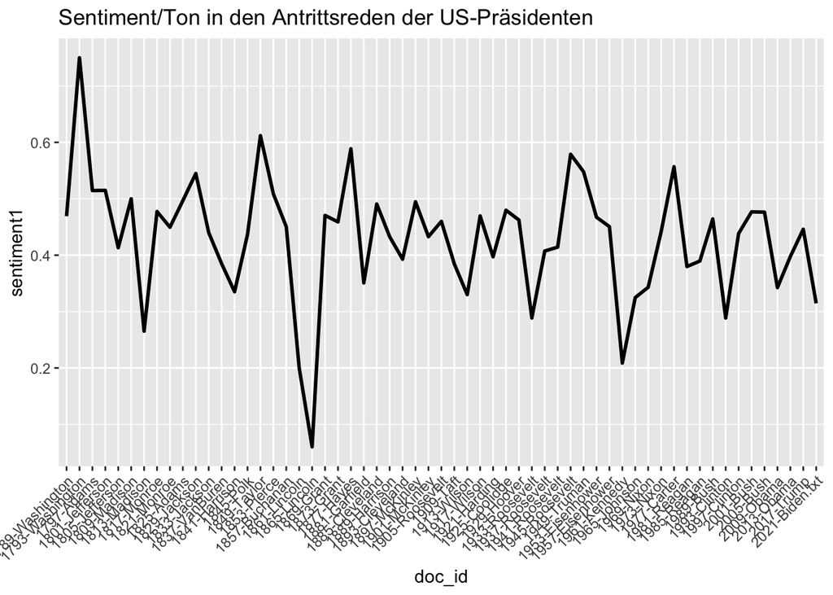

```r
library(ggplot2)

ggplot(result, aes(doc_id, sentiment1, group = 1)) + # Die Reden bilden die x-Achse und der Subjektivitätsmaß bildet die y-Achse
  geom_line(size = 1) +
  theme(axis.text.x = element_text(angle = 45, vjust = 1, hjust = 1)) +  # Hier definieren wir das Aussehen der Lables
  ggtitle("Sentiment/Ton in den Antrittsreden der US-Präsidenten") # Titel
```

Wollen wir die positiven und negativen Wörter getrennt visualisieren (also wie viele positive und wie viele negative Wörter eine Antrittsrede enthält), dann können wir beispielhaft wie folgt vorgehen:

```r
dtm_speeches <- dfm_lookup(dtm_speeches,GI_dict) # Hier wiederholen wir die Anwendung des Wörterbuchs

sentiment <- convert(dtm_speeches, "data.frame") %>%
  gather(positive, negative, key = "Polarität", value = "Wörter") %>%
  mutate(doc_id = as_factor(doc_id)) %>%
  rename(Reden = doc_id)  # Wir erstellen einen eigenen Datensatz mit dem Namen "Sentiment" und generieren neue Variablen (Polarität, Wörter) bzw. benennen Variablen um (doc_id wird zu "Reden")
head(sentiment)
```

```
##             Reden Polarität Wörter
## 1 1789-Washington  positive    119
## 2 1793-Washington  positive      7
## 3      1797-Adams  positive    234
## 4  1801-Jefferson  positive    178
## 5  1805-Jefferson  positive    171
## 6    1809-Madison  positive    117
```

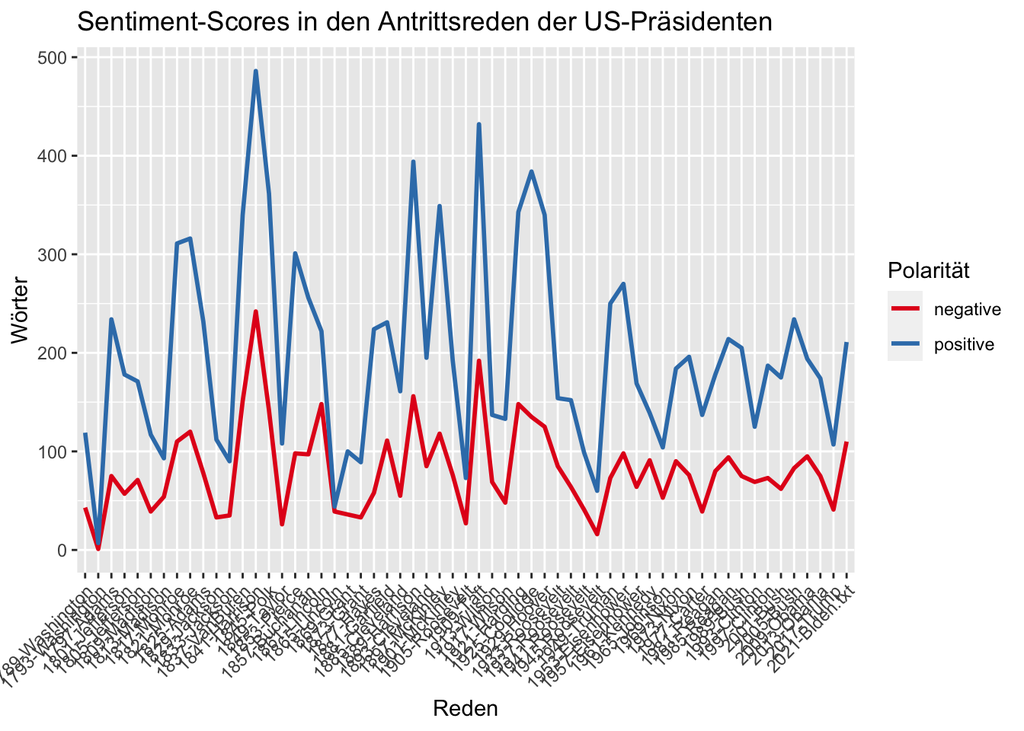

```r
ggplot(sentiment, aes(Reden, Wörter, colour = Polarität, group = Polarität)) +
  geom_line(size = 1) +
  scale_colour_brewer(palette = "Set1") +
  theme(axis.text.x = element_text(angle = 45, vjust = 1, hjust = 1)) +
  ggtitle("Sentiment-Scores in den Antrittsreden der US-Präsidenten")
```

# 4. Validierung

Die Validierung eines Wörterbuchs ist eine zentrale Aufagbe für jede Sentimentanalyse.

Um ein Maß für die Validität eines Wörterbuches zu erhalten, müssen wir eine Zufallstichprobe von Dokumenten manuell kodieren und die Kodierung mit den Eregbnissen des Wörterbuchs vergleichen. Manuelle Kodierungen gelten als Goldstandard, an dem sich automatische Kodierungen messen lassen müssen. Die Validierung einer jeden Textanalysemethode muss im Methodenabschnitt einer Forschungsarbeit berichtet und diskutiert werden.

Wie groß eine Zufallsstichprobe für eine Validierung sein sollte ist in der Wissenschaft umstritten. Hier gilt jedoch: je größer, desto genauer die Validierung. Das größte Problem bei manueller Kodierung ist die Ressourcenknappheit, weshalb kontextspezifisch ein gutes und realisierbares Maß gefunden (und in der Arbeit auch stichhaltig verargumentiert) werden muss.

Um eine Zufallsstichprobe aus der ursprünglichen DTM zu ziehen, können wir die Funktion `sample` anwenden:

```r
sample_speeches = sample(docnames(dtm_speeches), size=20) # wir wählen zufällig 20 Reden aus
```

Jetzt transformieren wir unseren Ausgangskorpus in einen Datensatz, fügen die Volltexte und Dokumentennamen hinzu. Danach filtern wir unsere zufällig ausgewählten Antrittsreden und kreieren eine csv.Datei. Diese Datei können wir anschließend für die manuelle Kodierung nutzen:

```r
# Korpus in Datensatz umwandeln
docs <- docvars(inaug_speeches) # Dokumentenvariablen
docs$doc_id <-  docnames(inaug_speeches) # Textnamen
docs$text <-  texts(inaug_speeches) # Volltexte der Reden

# Wir filtern unsere Zufallsstichprobe, kreieren die neue Variable "manual_coding" und schreiben dann eine csv.Datei (diese finden sich dann in dem Ordner von eurem R-Projekt oder dort wo ihr euer Skript abgespeichert habt)
docs %>% filter(document %in% sample_speeches) %>% mutate(manual_coding="") %>% write_csv("to_code.csv")
```

Jetzt können wir die csv.Datei in Excel/Pages (you name it) öffnen und die 20 zufällig ausgewählten Dokumente manuell kodieren. Anschließend müssen wir das Ergebnis wieder in `R` einlesen und mit den automatisch generierten Ergebnissen unserer Wörterbuchanalyse konbinieren:

```r
library(readr) # wir brauchen das paket um die csv zu speichern (vorher müsst ihr vielleicht install.packages("readr") ausführen)
validation <-  read_csv("to_code.csv") %>% mutate(doc_id=as.character(document)) %>% inner_join(result) # wir kombinieren hier unsere manuell kodieren reden mit unseren automatischen ergebnissen (das result-objekt)
```

Nun kontrollieren wir, wie gut meine (zugegebenermaßen **völlig zufällige**) manuelle Kodierung mit dem automatischen Sentiment-Score übereinstimmt. Zum Beispiel konnen wir eine Korrelation berechnen:

```r
cor.test(validation$manual_coding, validation$sentiment1)
```

```
##
##  Pearson's product-moment correlation
##
## data:  validation$manual_coding and validation$sentiment1
## t = 1.0177, df = 18, p-value = 0.3223
## alternative hypothesis: true correlation is not equal to 0
## 95 percent confidence interval:
##  -0.2333447  0.6125536
## sample estimates:
##       cor
## 0.2332628
```

```r
cor.test(validation$manual_coding, validation$sentiment2)
```

```
##
##  Pearson's product-moment correlation
##
## data:  validation$manual_coding and validation$sentiment2
## t = 1.0446, df = 18, p-value = 0.31
## alternative hypothesis: true correlation is not equal to 0
## 95 percent confidence interval:
##  -0.2275209  0.6163817
## sample estimates:
##       cor
## 0.2390701
```

Die Korrelationen zeigen keinen signifikanten Zusammenhang zwischen meiner manuellen Kodierung und der automatischen Kodierung. Hätte ich die Dokumente ernsthaft kodiert, dann wäre das ein schlechtes Zeichen für meine Wörterbuchanalyse und es würde bedeuten, dass ich mein Wörterbuch verbessern müsste.

Wir können auch eine 'Konfusionsmatrix' berechnen, wenn wir mit der Funktion `cut` einen Nominalwert aus dem Sentiment erzeugen:

```r
validation <-  validation %>%
  mutate(sent_nom = cut(sentiment1, breaks=c(0, 0.49, 0.51, 1), labels=c("-", "0", "+")))
con_matrix <-  table(manual = validation$manual_coding, dictionary = validation$sent_nom)
con_matrix
```

```
##         dictionary
## manual   - 0 +
##   0.123  1 0 0
##   0.134  1 0 0
##   0.222  1 0 0
##   0.245  1 0 0
##   0.31   0 0 1
##   0.312  1 0 0
##   0.45   1 0 0
##   0.457  1 0 0
##   0.5    0 0 1
##   0.523  0 0 1
##   0.5264 1 0 0
##   0.531  1 0 0
##   0.54   1 0 0
##   0.67   1 0 0
##   0.671  1 0 0
##   0.7    1 0 0
##   0.767  1 0 0
##   0.786  1 0 0
##   0.86   0 0 1
##   0.99   1 0 0
```

```r
sum(diag(con_matrix)) / sum(con_matrix)
```

```
## [1] 0.05
```

Die Ergebnisse würden bedeuten, dass unser Wörterbuch für die zu analysierenden Texte nicht funktioniert und das eine Verbesserung des Wörterbüches notwendig ist. Da ich die manuelle Kodierung jedoch vollkommen zufällig gemacht habe, sind die gefunden Validierungsergebnisse nicht aussagekräftig. Sie dienen lediglich als Anschauungsmaterial. **Bitte kodiert eure 20 Texte selber und schaut dann inwiefern sich die Validationsmaße verändern!**

# 5. Optimierung

```r
freqs <-  textstat_frequency(dtm_speeches)
freqs %>% as_tibble() %>% filter(feature %in% HL_dict$positive)
```

```
## # A tibble: 1 x 5
##   feature  frequency  rank docfreq group
##   <chr>        <dbl> <dbl>   <dbl> <chr>
## 1 positive     11794     1      59 all
```

Um das zu kontrollieren bietet sich vor allem die "Key-Word-in-Context"-Methode an. Bei dieser Methode definieren wir ein Zielwort und lassen uns eine Textsequenz vor und nach diesem Wort anzeigen (Die Länge der Sequenz ist optimierbar. Wie? Das könnt ihr mittels der help-Page herausfinden `?kwic`):

```r
inaug_speeches_toks <- tokens(inaug_speeches)
head(kwic(inaug_speeches_toks, "great"))
```

```
## Keyword-in-context with 6 matches.
##  [1789-Washington, 471]       tendering this homage to the | Great |
##  [1789-Washington, 735]               than to refer to the | great |
##  [1789-Washington, 862]           ought to watch over this | great |
##       [1797-Adams, 415] and insurrection, threatening some | great |
##       [1797-Adams, 553]                   , I read it with | great |
##       [1797-Adams, 602]      In its general principles and | great |
##
##  Author of every public and
##  constitutional charter under which you
##  assemblage of communities and interests
##  national calamity. In this
##  satisfaction, as the result
##  outlines it was conformable to
```

```r
head(kwic(inaug_speeches_toks, "peace"))
```

```
## Keyword-in-context with 6 matches.
##       [1797-Adams, 862]                 in its effects upon the | peace |
##      [1797-Adams, 1486]          of liberty to independence and | peace |
##      [1797-Adams, 1605]         secret enemies of his country's | peace |
##      [1797-Adams, 2038] an inflexible determination to maintain | peace |
##      [1797-Adams, 2268]               all nations, and maintain | peace |
##  [1801-Jefferson, 1229]               , religious or political; | peace |
##
##  , order, prosperity,
##  , to increasing wealth and
##  . This example has been
##  and inviolable faith with all
##  , friendship, and benevolence
##  , commerce, and honest
```

Daraus geht hervor, dass das Wort "peace" eher als neutraler Begriff verwendet wird und deswegen vermutlich unsere Positive/Negative-zentrierte Sentimentanalyse verzerrt. Um es aus der Liste der positiven Wörter zu entfernen, können wir die Funktion `setdiff` (Differenz zwischen zwei Mengen) verwenden:

```r
positive.cleaned <- setdiff(positive.words, c("peace"))
HL_dict2 <-  dictionary(list(positive=positive.cleaned, negative=negation.words))
```

```r
freqs_pos <- freqs %>% filter(feature %in% HL_dict2$positive)
head(freqs_pos)
```

```
##    feature frequency rank docfreq group
## 1 positive     11794    1      59   all
```

Für weitere nützliche Hinweise und Beispiele empfehle ich euch die Internetseite von Cornelius Puschmann: http://inhaltsanalyse-mit-r.de/sentiment.html